# Background

`critbit.move` structures are as follows (comments removed for brevity):

```
struct CritBitTree<V> has store {
    root: u64,
    inner_nodes: vector<InnerNode>,
    outer_nodes: vector<OuterNode<V>>
}

struct InnerNode has store {
    critical_bit: u8,
    parent_index: u64,
    left_child_index: u64,
    right_child_index: u64
}

struct OuterNode<V> has store {
    key: u128,
    value: V,
    parent_index: u64,
}
```

`critqueue.benchmark` uses an `address` for `V`, yielding the following byte sizes:

```python
inner_node_size_bytes = 1 + 8 + 8 + 8
inner_node_size_bytes
```

```
25
```

```python
outer_node_size_bytes = 16 + 32 + 8 # 32-byte address.
outer_node_size_bytes
```

```
56
```

```python
bytes_per_key = inner_node_size_bytes + outer_node_size_bytes
bytes_per_key
```

```
81
```

Per the [storage gas optimization principles](https://aptos.dev/concepts/base-gas/#storage-gas-1), per-byte writes cost 0.02 octals and per-item writes cost 40 octals:

```python
gas_per_written_byte = 0.02
gas_per_written_byte
```

```
0.02
```

```python
gas_per_written_item = 40
gas_per_written_item
```

```
40
```

And for reads:

```python
gas_per_read_byte = 0.004
gas_per_read_byte
```

```
0.004
```

```python
gas_per_read_item = 8
gas_per_read_item
```

```
8
```

```python
min_gas = 1_500_000 / 10_000
min_gas
```

```
150.0
```

With all data contained in a single item in global storage, read and write operation costs can thus be approximated by the number of keys in the tree:

```python
def expected_read_cost(n_keys) -> int:
    # Borrow `TreeStore`, borrow `CritBitTree`,
    # then read the bytes within.
    return int(min_gas + \
    + gas_per_read_item \
    + gas_per_read_item \
    + n_keys * bytes_per_key * gas_per_read_byte)
```

```python
expected_read_cost(1)
```

```
166
```

```python
expected_read_cost(10)
```

```
169
```

```python
expected_read_cost(100)
```

```
198
```

```python
expected_read_cost(1000)
```

```
490
```

```python
def expected_write_cost(n_keys) -> int:
    # Borrow `TreeStore`, borrow `CritBitTree`,
    # then read the bytes within.
    return int(min_gas + \
    + gas_per_read_item \
    + gas_per_written_item \
    + n_keys * bytes_per_key * gas_per_written_byte)
```

```python
expected_write_cost(1)
```

```
199
```

```python
expected_write_cost(10)
```

```
214
```

```python
expected_write_cost(100)
```

```
360
```

```python
expected_write_cost(1000)
```

```
1818
```

# Imports

```python
import pandas as pd
import time

from aptos_sdk.account import Account
from aptos_sdk.bcs import Serializer
from aptos_sdk.client import RestClient, FaucetClient
from aptos_sdk.transactions import (
    EntryFunction,
    ModuleId,
    TransactionArgument as TxArg,
    TransactionPayload as TxPayload)
from aptos_sdk.type_tag import StructTag
from IPython.display import clear_output
from typing import Any, Dict
from pathlib import Path
```

# Account via keyfile

```python
# Relative path to hot keyfile for testing only.
# File should contain hex key only.`
key_file = sorted(Path('../../.secrets').glob('*.key'))[0]
with open(key_file) as f: # Open file.
    key = f.readline().rstrip() # Get key.
# Get account from key.
account = Account.load_key(key)
# Print account address in hex.
account.address().hex()
```

```
'0x2998ef92ac30091be863e3ebf5460e02d912d1470c77ae8eff626198b71ead6c'
```

# REST Client

```python
# Declare base URL for devnet REST API.
client_url = 'https://fullnode.devnet.aptoslabs.com/v1'
# Declare base URL for faucet.
faucet_url = 'https://faucet.devnet.aptoslabs.com'
# Initialize client.
client = RestClient(client_url)
# Initialize faucet.
faucet = FaucetClient(faucet_url, client)
# Get account balance
client.account_balance(account.address())
```

```
'98803200'
```

```python
# Fund from the faucet
faucet.fund_account(account.address().hex(), 1000000000)
```

```python
# Get account balance
client.account_balance(account.address())
```

[output not shown]

```python
def execute(function: str, args: list) -> str:
    """Call entry function with args, returning tx hash

    args should be of format
    [[4, Serializer.u64], [2, Serializer.u128]]
    """
    # Construct entry function payload.
    payload = EntryFunction.natural(
        str(module_id),
        function,
        [],
        [TxArg(a[0], a[1]) for a in args])
    # Generate a signed transaction from the payload.
    signed_tx = client.create_single_signer_bcs_transaction(
        account, TxPayload(payload))
    # Submit signed transaction, returning transaction ID.
    return client.submit_bcs_transaction(signed_tx)
```

```python
def get_tx_json(hash: str) -> Dict[str, Any]:
    """Query a transaction by hash, returning JSON data"""
    while(True):
        response = client.client.get(
            f'{client.base_url}/transactions/by_hash/{hash}')
        # Assert successful response.
        assert response.status_code == 200, hash
        # If transaction has cleared as user tx:
        if response.json()['type'] == 'user_transaction':
            # Return its JSON data.
            return response.json()
        # Otherwise try again, after waiting.
        time.sleep(0.5) # Else you might get rate-limited.
```

```python
def print_tx_url(version: str):
    """Print URL to transaction view on explorer"""
    explorer = 'https://aptos-explorer.netlify.app'
    print(f'{explorer}/txn/{version}')
```

```python
def tx_diagnostics(tx_json: Dict[str, Any]):
    """Print gas used or link to failed tx"""
    if tx_json['success'] == True:
        print(f'Gas used: {tx_json["gas_used"]}')
    else:
        print_tx_url(tx_json['version'])
```

# Critbit interface

```python
# Declare module name.
module = 'critbit_benchmark'
# Get module ID.
module_id = ModuleId(account.address(), module)
# Get tree store struct tag.
struct_tag = StructTag(account.address(),
                       module,
                      'TreeStore',
                       [])
# Check that account has one.
client.account_resource(account.address(),
                        struct_tag.__str__())
```

```
{'type': '0x2998ef92ac30091be863e3ebf5460e02d912d1470c77ae8eff626198b71ead6c::critbit_benchmark::TreeStore',
 'data': {'map': {'inner': {'handle': '0x1512e7aa41e0bf18a74dfab2097420444e461a3e47a6293264277ea50cd67e0b'},
   'length': '1'}}}
```

```python
def insert(key: int) -> str:
    """Insert given key, returning tx ID"""
    return execute('insert', [
        [key, Serializer.u128],
    ])
```

```python
def pop(key: int) -> str:
    """Pop given key, returning tx ID"""
    return execute('pop', [
        [key, Serializer.u128],
    ])
```

```python
def pop_twice(key_1: int, key_2: int) -> str:
    """Pop given keys, returning tx ID"""
    return execute('pop_twice', [
        [key_1, Serializer.u128],
        [key_2, Serializer.u128],
    ])
```

```python
def borrow(key: int) -> str:
    """Pop given key, returning tx ID"""
    return execute('borrow', [
        [key, Serializer.u128],
    ])
```

```python
def clear() -> str:
    """Clear `CritBitTree`, returning tx ID"""
    return execute('clear', [])
```

```python
def reset() -> str:
    """Reset `TreeStore`, returning tx ID"""
    return execute('reset', [])
```

```python
# Reset.
tx_diagnostics(get_tx_json(reset()))
```

```
Gas used: 409
```

# Simple operations

Insert a single key:

```python
expected_write_cost(1)
```

```
199
```

```python
tx_diagnostics(get_tx_json(insert(1)))
```

```
Gas used: 205
```

Immutably borrow the single key:

```python
expected_read_cost(1)
```

```
166
```

```python
tx_diagnostics(get_tx_json(borrow(1)))
```

```
Gas used: 163
```

Pop the key:

```python
expected_write_cost(1)
```

```
199
```

```python
tx_diagnostics(get_tx_json(pop(1)))
```

```
Gas used: 203
```

# Unbalanced insertion

Insert keys in the following prder, creating an unbalanced tree of maximum height:

1. `0b0`
2. `0b10`
3. `0b100`

...

1. `0b10000...`

Here, each successive insertion has to walk more nodes during a search, producing the following tree:

> ```
>               127th
>              /     \
>           126th    100000000000000.....
>         ...
>        2nd
>       /   \
>     1st   100
>    /   \
>  0th   10
> /   \
> 0   1
> ```

In particular, by inserting smaller keys first, the insertion algorithm has to walk all the way down then all the way back up the tree.

```python
# Reset tree store, waiting until tx clears.
tx_diagnostics(get_tx_json(reset()))
# Init log for bit number, expected
# gas, and actual gas used.
gas = []
for i in range (128): # Loop over all bits:
    key = 0 # Assume no bitshift.
    if i != 0: # If should shift.
        key = 1 << i # Shift accordingly.
    # Store JSON for key insertion tx.
    tx_json = get_tx_json(insert(key))
    # Assert successful tx.
    assert tx_json['success'] == True
    # Log expected and actual gas for shift.
    insert_gas = {
        'height': i,
        'gas_expected': expected_write_cost(i + 1),
        'gas_actual': int(tx_json['gas_used'])
    }
    gas.append(insert_gas) # Append to gas log.
    # Print gas used.
    print(f'Post-insertion height: {insert_gas["height"]}, '
          f'expected gas: {insert_gas["gas_expected"]}, '
          f'actual gas: {insert_gas["gas_actual"]}')
    clear_output(wait=True) # Clear terminal output.
```

```
Post-insertion height: 127, expected gas: 405, actual gas: 610
```

Plot results, noting that expected gas costs do not account for instruction costs associated with traversal:

```python
df = pd.DataFrame(gas)
```

```
(0.0, 630.55)
```

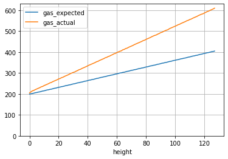

```python
ax = df.plot(x='height',
             y='gas_expected')
df.plot(x='height',
        y='gas_actual',
        grid=True,
        ax=ax);
ax.set_ylim(ymin=0)
```

Repeat, but insert at the bottom of the tree instead of the top:

```python
# Reset tree store, waiting until tx clears.
tx_diagnostics(get_tx_json(reset()))
# Init log for bit number, expected
# gas, and actual gas used.
gas = []
n_bits = 128 # Number of bits in a key.
for i in range (n_bits): # Loop over all bits:
    key = 0 # Assume no bitshift.
    if i != n_bits - 1: # If should shift.
         # Shift accordingly.
        key = 1 << (n_bits - 1 - i)
    # Store JSON for key insertion tx.
    tx_json = get_tx_json(insert(key))
    # Assert successful tx.
    assert tx_json['success'] == True
    # Log expected and actual gas for shift.
    insert_gas = {
        'height': i,
        'gas_expected': expected_write_cost(i + 1),
        'gas_actual': int(tx_json['gas_used'])
    }
    gas.append(insert_gas) # Append to gas log.
    # Print gas used.
    print(f'Post-insertion height: {insert_gas["height"]}, '
          f'expected gas: {insert_gas["gas_expected"]}, '
          f'actual gas: {insert_gas["gas_actual"]}')
    clear_output(wait=True) # Clear terminal output.
```

```
Post-insertion height: 127, expected gas: 405, actual gas: 562
```

Now traversal instructions are effectively cut in half, but estimates are still off:

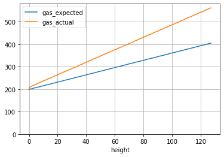

```python
df2 = pd.DataFrame(gas)
ax2 = df2.plot(x='height',
               y='gas_expected')
df2.plot(x='height',
         y='gas_actual',
         grid=True,
         ax=ax2);
ax2.set_ylim(ymin=0);
```

# Balanced insertion, lookup, removal

For a balanced tree, instead insert the values:

- `0b00000000`
- `0b00000001`
- `0b00000010`
- `0b00000011`

...

- `0b11111111`

```python
# Reset tree store, waiting until tx clears.
tx_diagnostics(get_tx_json(reset()))
# Init log for bit number, expected
# gas, and actual gas used.
gas = []
for i in range (128): # Loop over all bits:
    # Store JSON for key insertion tx.
    tx_json = get_tx_json(insert(i))
    # Assert successful tx.
    assert tx_json['success'] == True
    # Log expected and actual gas for shift.
    insert_gas = {
        'n_keys': i,
        'gas_expected': expected_write_cost(i + 1),
        'gas_actual': int(tx_json['gas_used'])
    }
    gas.append(insert_gas) # Append to gas log.
    # Print gas used.
    print(f'Pre-insertion leaf count: {insert_gas["n_keys"]}, '
          f'expected gas: {insert_gas["gas_expected"]}, '
          f'actual gas: {insert_gas["gas_actual"]}')
    clear_output(wait=True) # Clear terminal output.
```

```
Pre-insertion leaf count: 127, expected gas: 405, actual gas: 424
```

Actual gas values are now more closely approximated by pure storage gas costs:

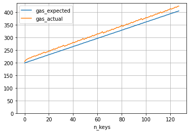

```python
df3 = pd.DataFrame(gas)
ax3 = df3.plot(x='n_keys',
               y='gas_expected')
df3.plot(x='n_keys',
         y='gas_actual',
         grid=True,
         ax=ax3);
ax3.set_ylim(ymin=0);
```

Here, each time a new bit gets set, e.g. after `0b00011111` has been inserted and then `0b00100000` gets inserted, insertion requires walking down the tree and then back up to the root to insert above. Hence the 7 spikes in gas costs at regular intervals.

Borrowing is a single read operation:

```python
expected_read_cost(128)
```

```
207
```

```python
tx_diagnostics(get_tx_json(borrow(1)))
```

```
Gas used: 171
```

Removing is a single write operation:

```python
expected_write_cost(128)
```

```
405
```

```python
tx_diagnostics(get_tx_json(pop(1)))
```

```
Gas used: 430
```

Clearing out all elements is also a single write operation, but requires extensive iteration:

```python
expected_write_cost(127)
```

```
403
```

```python
tx_diagnostics(get_tx_json(clear()))
```

```
Gas used: 3036
```

# Access multiplicity

First insert 3 keys:

```python
# Reset tree store, waiting until tx clears.
tx_diagnostics(get_tx_json(reset()))
tx_diagnostics(get_tx_json(insert(1)))
tx_diagnostics(get_tx_json(insert(2)))
tx_diagnostics(get_tx_json(insert(3)))
```

```
Gas used: 409
Gas used: 205
Gas used: 210
Gas used: 214
```

Here, the `pop` function borrows the `TreeStore`, then operates on the `CritBitTree`, for a single per-item write:

```python
expected_write_cost(3)
```

```
202
```

```python
tx_diagnostics(get_tx_json(pop(3)))
```

```
Gas used: 214
```

The `pop_twice` function repeates the process twice in a single transaction, returning in between: it reads the `TreeStore`, then writes to the `CritBitTree`, then returns, then reads the `TreeStore`, then again writes to the `CritBitTree`. Yet because the same item in global memory is written to each time, the transaction is only assessed a single per-item write:

```python
expected_write_cost(2)
```

```
201
```

```python
tx_diagnostics(get_tx_json(pop_twice(1, 2)))
```

```
Gas used: 215
```